# THE SPARKS FOUNDATION

TASK 1 - Prediction using Supervised Machine Learning

Predict the percentage of a student based on the no. of study hours.

#### Done By: Angel Mary Abraham Korandithara

### **Importing the Packages**

```r
library(dplyr)
```

```r
library(ggplot2)
library(corrplot)
```

### **Importing the Dataset**

```r
# loading the dataset from the url provided

data = read.csv(url("http://bit.ly/w-data"))
head(data)
```

|  | Hours | Scores |
| --- | --- | --- |
| 1 | 2.5 | 21 |
| 2 | 5.1 | 47 |
| 3 | 3.2 | 27 |
| 4 | 8.5 | 75 |
| 5 | 3.5 | 30 |
| 6 | 1.5 | 20 |

```r
#taking the dimension of the dataset

dim(data)
```

```
## [1] 25  2
```

*The dataset contains 25 observations with 2 variables.*

```r
#finding the Column names

colnames(data)
```

```
## [1] "Hours"  "Scores"
```

*Hours and Scores are the two variables present in the dataset.*

### **DATA PREPROCESSING**

```r
#checking for NAN values

colSums(is.na(data))
```

```
##  Hours Scores
##      0      0
```

*The given dataset contains no NaN values.*

```r
#checking NULL values

is.null(data)
```

```
## [1] FALSE
```

*The given dataset contain no NULL values.*

### **EXPLORATORY DATA ANALYSIS**

```r
#structure of the dataset

str(data)
```

```
## 'data.frame':    25 obs. of  2 variables:
##  $ Hours : num  2.5 5.1 3.2 8.5 3.5 1.5 9.2 5.5 8.3 2.7 ...
##  $ Scores: int  21 47 27 75 30 20 88 60 81 25 ...
```

*The variable Hours is of type Numeric and Scores is of datatype Integer.*

```r
#SUMMARY OF THE DATASET

summary(data)
```

```
##      Hours           Scores
##  Min.   :1.100   Min.   :17.00
##  1st Qu.:2.700   1st Qu.:30.00
##  Median :4.800   Median :47.00
##  Mean   :5.012   Mean   :51.48
##  3rd Qu.:7.400   3rd Qu.:75.00
##  Max.   :9.200   Max.   :95.00
```

- The Minimum value of Hours is 1.100 and maximum value is 9.200. Mean value is greater than median value. Hence it is right skewed.
- The Minimum value of Scores is 17.00 and maximum value is 95.00. Mean value is greater than median value. Hence it is right skewed.

**BOXPLOT**

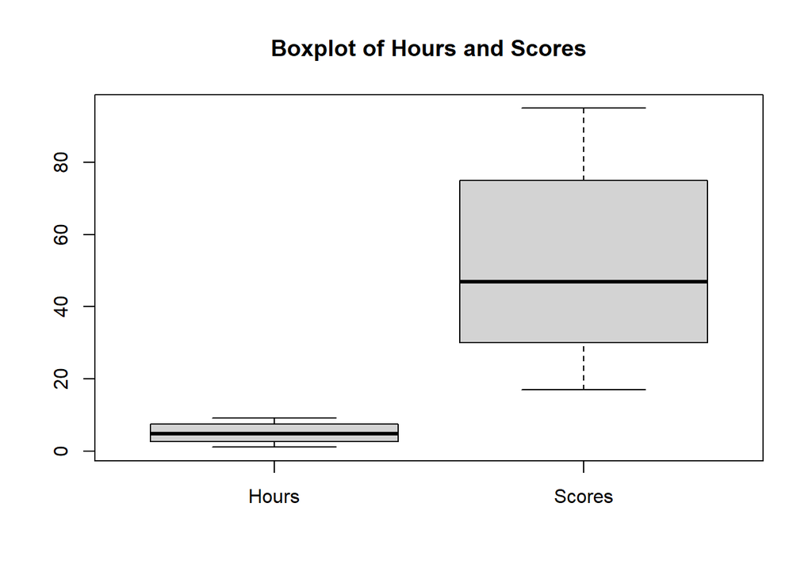

```r
#Checking the outliers

#library(ggplot2)
boxplot(data,main='Boxplot of Hours and Scores')
```

*From the boxplot, we can understand that No outliers are present in the dataset.*

**SCATTERPLOT**

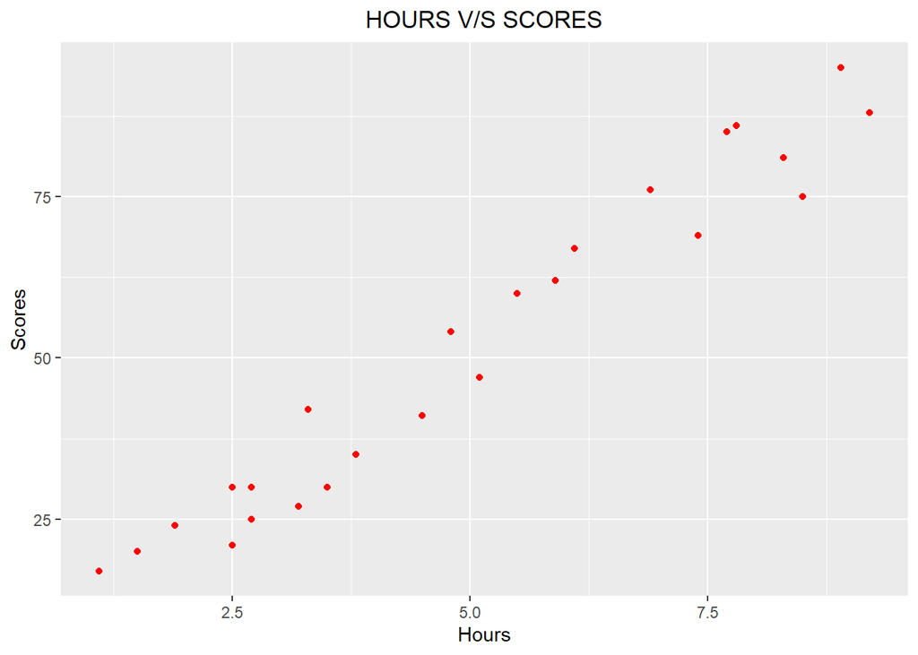

```r
library(ggplot2)
my_graph <- ggplot(data,
                    aes(x =Hours, y =Scores))+
                    ggtitle('HOURS V/S SCORES')+
                    theme(plot.title = element_text(hjust = 0.5))+
                    geom_point(col='red')

my_graph
```

*From the graph we can see that there is a linear relationship between the response variable and explanatory variable. Also the direction of association seems to be positive i.e. As Hours increase, the Scores obtained also increase and vice-versa.*

**CORRELATION**

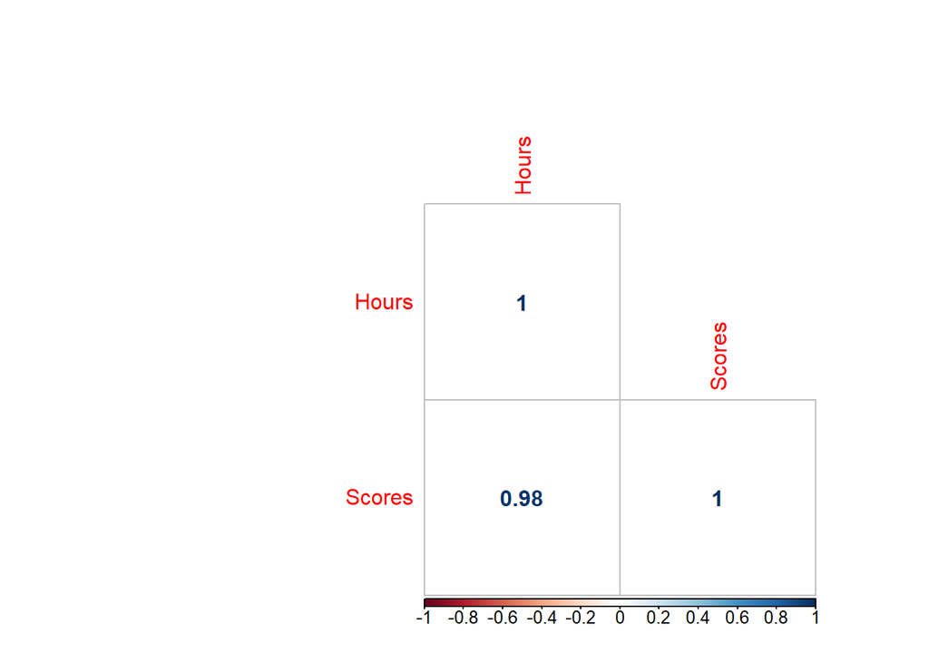

```r
#library(corrplot)
corrplot(cor(data),
method ='number',
type = 'lower' # show only lower side
)
```

```r
#using pearson correlation

cor.test(data$Hours,data$Scores)
```

```
##
##  Pearson's product-moment correlation
##
## data:  data$Hours and data$Scores
## t = 21.583, df = 23, p-value < 2.2e-16
## alternative hypothesis: true correlation is not equal to 0
## 95 percent confidence interval:
##  0.9459248 0.9896072
## sample estimates:
##       cor
## 0.9761907
```

*Here, the correlation value is 0.9761907. Hence, we can understand that there exists a high positive correlation between Hours and Scores.*

### **DATA MODELLING**

*Train Test Splitting*

```r
set.seed(100)
rows=sample(nrow(data))

#Randomly order data
data=data[rows,]
#Identify row to split on: split
split = round(nrow(data) * .80)
```

```r
#Create train
train=data[1:split,]
#Create test
test=data[(split+1):nrow(data),]
```

**Linear Regression Model**

```r
#fitting linear regression model
linmod = lm(Scores~Hours, data = train)

#taking the summary of the model
summary(linmod)
```

```
##
## Call:
## lm(formula = Scores ~ Hours, data = train)
##
## Residuals:
##    Min     1Q Median     3Q    Max
## -8.983 -4.624  1.614  4.579  7.252
##
## Coefficients:
##             Estimate Std. Error t value Pr(>|t|)
## (Intercept)   3.5030     2.9013   1.207    0.243
## Hours         9.4682     0.5367  17.643 8.29e-13 ***
## ---
## Signif. codes:  0 '***' 0.001 '**' 0.01 '*' 0.05 '.' 0.1 ' ' 1
##
## Residual standard error: 5.508 on 18 degrees of freedom
## Multiple R-squared:  0.9453, Adjusted R-squared:  0.9423
## F-statistic: 311.3 on 1 and 18 DF,  p-value: 8.29e-13
```

The value of intercept of the linear model is 3.5030. The slope of the model is 9.4682. Hence,the model can be interpreted as : $Scores = 9.4682 * Hours + 3.5030$.

*Predicting the Scores*

```r
Pred = predict(linmod, test)
```

*Comparing The Actual and Predicted Scores*

```r
data.frame(Actual=test$Scores,Predicted=Pred)
```

|  | Actual | Predicted |
| --- | --- | --- |
| 15 | 17 | 13.91803 |
| 11 | 85 | 76.40841 |
| 9 | 81 | 82.08936 |
| 1 | 21 | 27.17356 |
| 25 | 86 | 77.35524 |

*Comparing The Actual and Predicted Values using Data Visualisation*

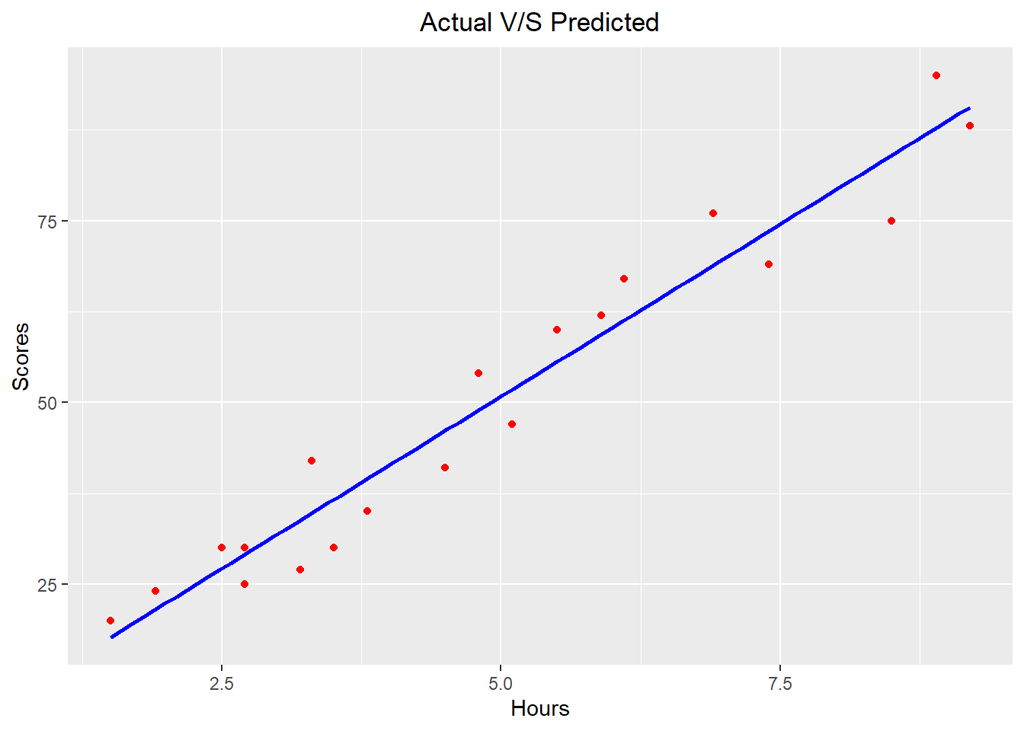

```r
#library(ggplot2)
my_graph <- ggplot(train,
                    aes(x =Hours, y =Scores))+
                    ggtitle('Actual V/S Predicted')+
                    theme(plot.title = element_text(hjust = 0.5))+
                    geom_point(col='red')+
                    stat_smooth(method = 'lm',
                    col = 'blue',
                    se = FALSE,
                    size = 1)

my_graph
```

#### **What will be the predicted score if the student studies for 9.25 hr/day?**

```r
test2 = data.frame(Hours = 9.25)
predict(linmod, test2)
```

```
##        1
## 91.08419
```

*Therefore, according to the regression model, if a student studies for 9.25 hours per day he/she is likely to score 91.08419.*